# mod5_mcspadden_diana

Diana McSpadden

3/14/2021

# Question 8

In this exercise, we will generate simulated data, and will then use this data to perform best subset selection.

## Q8 (a)

Use the rnorm() function to generate a predictor X of length n = 100, as well as a noise vector E of length n = 100.

```r
set.seed (1976)

X = rnorm(100)

E = rnorm (100)
```

## Q8 (b)

Generate a response vector Y of length n = 100 according to the model:

Y = β0 + β1X + β2X2 + β3X3 + E,

where β0, β1, β2, and β3 are constants of your choice.

```r
B0 = 10
B1 = -13
B2 = 3.27
B3 = -9.11

Y = B0 + (B1 * X) + (B2 * X^2) + (B3 * X^3) + E
```

## Q8 (c)

Use the regsubsets() function to perform best subset selection in order to choose the best model containing the predictors X,X2, . . .,X10.

```r
df.q8c = data.frame(x1 = X, x2 = X^2, x3 = X^3, x4 = X^4, x5 = X^5, x6 = X^6, x7 = X^7, x8 = X^8, x9 = X^9, x10 = X^10, y = Y)

head(df.q8c)
```

```
##           x1          x2            x3           x4            x5           x6
## 1  0.9237233 0.853264801  0.7881806085 7.280608e-01  6.725268e-01 6.212287e-01
## 2 -1.7868278 3.192753614 -5.7049009408 1.019368e+01 -1.821434e+01 3.254589e+01
## 3 -1.2641727 1.598132687 -2.0203157590 2.554028e+00 -3.228733e+00 4.081676e+00
## 4  0.5632750 0.317278775  0.1787152157 1.006658e-01  5.670254e-02 3.193913e-02
## 5 -0.0699854 0.004897956 -0.0003427854 2.398998e-05 -1.678948e-06 1.175018e-07
## 6  0.1009554 0.010192000  0.0010289378 1.038769e-04  1.048693e-05 1.058713e-06
##              x7           x8            x9          x10         y
## 1  5.738434e-01 5.300726e-01  4.896404e-01 4.522923e-01 -6.236479
## 2 -5.815391e+01 1.039110e+02 -1.856711e+02 3.317623e+02 96.680395
## 3 -5.159943e+00 6.523059e+00 -8.246274e+00 1.042471e+01 51.205620
## 4  1.799051e-02 1.013361e-02  5.708008e-03 3.215179e-03  2.080597
## 5 -8.223414e-09 5.755189e-10 -4.027792e-11 2.818866e-12 11.971436
## 6  1.068828e-07 1.079040e-08  1.089350e-09 1.099758e-10  9.259731
```

```r
library(leaps)
regfit.full <- leaps::regsubsets(y~., data = df.q8c, nvmax=10)
#summary(regfit.full)
regfit.full %>% broom::tidy()
```

```
## # A tibble: 10 x 15
##    `(Intercept)` x1    x2    x3    x4    x5    x6    x7    x8    x9    x10
##    <lgl>         <lgl> <lgl> <lgl> <lgl> <lgl> <lgl> <lgl> <lgl> <lgl> <lgl>
##  1 TRUE          FALSE FALSE TRUE  FALSE FALSE FALSE FALSE FALSE FALSE FALSE
##  2 TRUE          TRUE  FALSE TRUE  FALSE FALSE FALSE FALSE FALSE FALSE FALSE
##  3 TRUE          TRUE  TRUE  TRUE  FALSE FALSE FALSE FALSE FALSE FALSE FALSE
##  4 TRUE          TRUE  TRUE  TRUE  TRUE  FALSE FALSE FALSE FALSE FALSE FALSE
##  5 TRUE          TRUE  TRUE  TRUE  FALSE FALSE FALSE FALSE TRUE  FALSE TRUE
##  6 TRUE          TRUE  TRUE  TRUE  FALSE FALSE FALSE TRUE  FALSE TRUE  TRUE
##  7 TRUE          TRUE  TRUE  TRUE  FALSE TRUE  FALSE TRUE  FALSE TRUE  TRUE
##  8 TRUE          TRUE  TRUE  TRUE  FALSE TRUE  FALSE TRUE  TRUE  TRUE  TRUE
##  9 TRUE          TRUE  TRUE  TRUE  FALSE TRUE  TRUE  TRUE  TRUE  TRUE  TRUE
## 10 TRUE          TRUE  TRUE  TRUE  TRUE  TRUE  TRUE  TRUE  TRUE  TRUE  TRUE
## # ... with 4 more variables: r.squared <dbl>, adj.r.squared <dbl>, BIC <dbl>,
## #   mallows_cp <dbl>
```

```r
reg.summary = regfit.full %>% broom::tidy()

#reg.summary %>% names()
#reg.summary %>% dplyr::select(adj.r.squared)
#reg.summary %>% dplyr::select(BIC)
#reg.summary %>% dplyr::select(mallows_cp)
```

What is the best model obtained according to Cp, BIC, and adjusted R2?

Show some plots to provide evidence for your answer, and report the coefficients of the best model obtained. Note you will need to use the data.frame() function to create a single data set containing both X and Y.

```r
adjR2s_plot = function(model.summary, xlab) {
  model.summary %>%
  ggplot(aes(x=seq_along(adj.r.squared), y=adj.r.squared)) + geom_line() +
  geom_point(model.summary, color='red', size=2, mapping=aes(x=which.max(adj.r.squared), y=max(adj.r.squared)))  + xlab(xlab)
}

mallows_cps_plot = function(model.summary, xlab) {
  model.summary %>%
  ggplot(aes(x=seq_along(mallows_cp), y=mallows_cp)) + geom_line() +
  geom_point(model.summary, color='red', size=2, mapping=aes(x=which.min(mallows_cp), y=min(mallows_cp))) +  xlab(xlab)
}

BICs_plot = function(model.summary, xlab) {
  model.summary %>%
  ggplot(aes(x=seq_along(BIC), y=BIC)) + geom_line() +
  geom_point(model.summary, color='red', size=2, mapping=aes(x=which.min(BIC), y=min(BIC))) +  xlab(xlab)
}
```

```r
library(gridExtra)
```

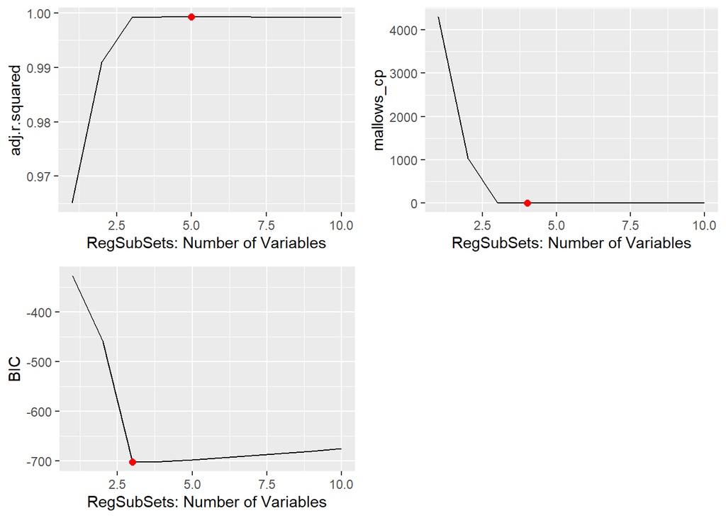

```r
grid.arrange(adjR2s_plot(reg.summary, "RegSubSets: Number of Variables"), mallows_cps_plot(reg.summary, "RegSubSets: Number of Variables"), BICs_plot(reg.summary, "RegSubSets: Number of Variables"), nrow=2)
```

## Q8 (d)

Repeat (c), using forward step-wise selection and also using backwards step-wise selection. How does your answer compare to the results in (c)?

#### Forward

```r
regfit.fwd <- regsubsets(y~., data=df.q8c, nvmax=10, method="forward")
#summary(regfit.fwd)
regfit.fwd.summary = regfit.fwd %>% broom::tidy()

regfit.fwd.summary
```

```
## # A tibble: 10 x 15
##    `(Intercept)` x1    x2    x3    x4    x5    x6    x7    x8    x9    x10
##    <lgl>         <lgl> <lgl> <lgl> <lgl> <lgl> <lgl> <lgl> <lgl> <lgl> <lgl>
##  1 TRUE          FALSE FALSE TRUE  FALSE FALSE FALSE FALSE FALSE FALSE FALSE
##  2 TRUE          TRUE  FALSE TRUE  FALSE FALSE FALSE FALSE FALSE FALSE FALSE
##  3 TRUE          TRUE  TRUE  TRUE  FALSE FALSE FALSE FALSE FALSE FALSE FALSE
##  4 TRUE          TRUE  TRUE  TRUE  TRUE  FALSE FALSE FALSE FALSE FALSE FALSE
##  5 TRUE          TRUE  TRUE  TRUE  TRUE  FALSE FALSE FALSE FALSE FALSE TRUE
##  6 TRUE          TRUE  TRUE  TRUE  TRUE  FALSE FALSE FALSE TRUE  FALSE TRUE
##  7 TRUE          TRUE  TRUE  TRUE  TRUE  TRUE  FALSE FALSE TRUE  FALSE TRUE
##  8 TRUE          TRUE  TRUE  TRUE  TRUE  TRUE  TRUE  FALSE TRUE  FALSE TRUE
##  9 TRUE          TRUE  TRUE  TRUE  TRUE  TRUE  TRUE  FALSE TRUE  TRUE  TRUE
## 10 TRUE          TRUE  TRUE  TRUE  TRUE  TRUE  TRUE  TRUE  TRUE  TRUE  TRUE
## # ... with 4 more variables: r.squared <dbl>, adj.r.squared <dbl>, BIC <dbl>,
## #   mallows_cp <dbl>
```

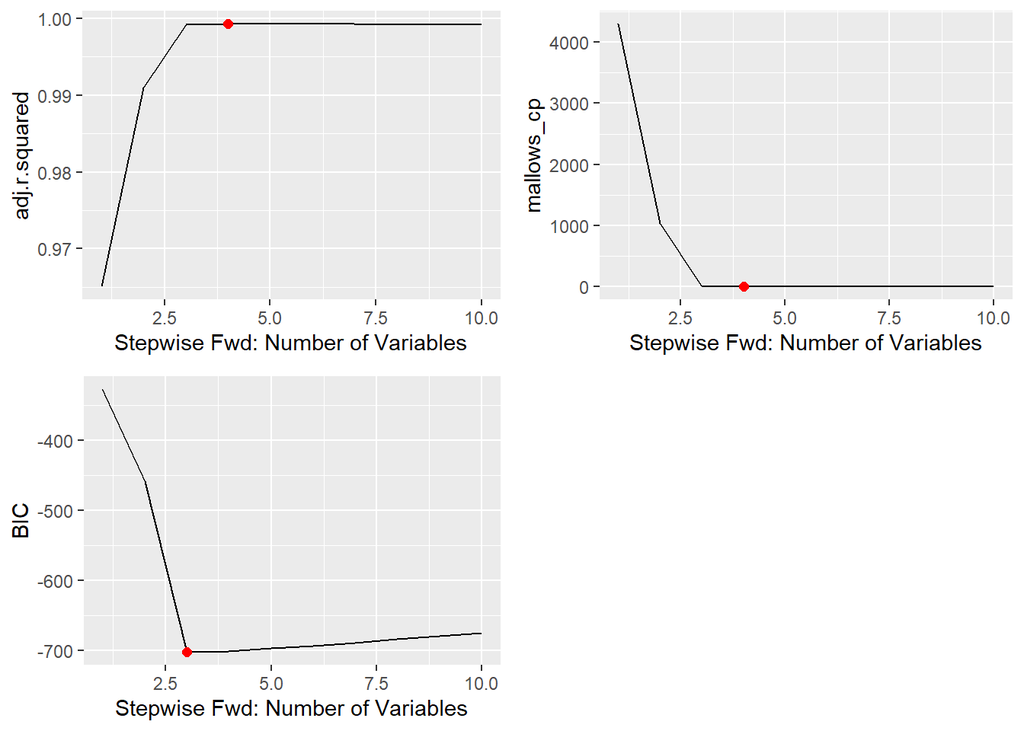

```r
grid.arrange(adjR2s_plot(regfit.fwd.summary, "Stepwise Fwd: Number of Variables"), mallows_cps_plot(regfit.fwd.summary, "Stepwise Fwd: Number of Variables"), BICs_plot(regfit.fwd.summary, "Stepwise Fwd: Number of Variables"), nrow=2)
```

Using forward step-wise selection, the best Adjusted R^2 Model is now the same as the best Mallow’s Cp model which was not true with the regsubsets.

#### Backward

```r
regfit.bwd <- regsubsets(y~., data=df.q8c, nvmax=10, method="backward")
#summary(regfit.bwd)
regfit.bwd.sumary = regfit.bwd %>% broom::tidy()

regfit.bwd.sumary
```

```
## # A tibble: 10 x 15
##    `(Intercept)` x1    x2    x3    x4    x5    x6    x7    x8    x9    x10
##    <lgl>         <lgl> <lgl> <lgl> <lgl> <lgl> <lgl> <lgl> <lgl> <lgl> <lgl>
##  1 TRUE          FALSE FALSE TRUE  FALSE FALSE FALSE FALSE FALSE FALSE FALSE
##  2 TRUE          TRUE  FALSE TRUE  FALSE FALSE FALSE FALSE FALSE FALSE FALSE
##  3 TRUE          TRUE  TRUE  TRUE  FALSE FALSE FALSE FALSE FALSE FALSE FALSE
##  4 TRUE          TRUE  TRUE  TRUE  FALSE FALSE FALSE TRUE  FALSE FALSE FALSE
##  5 TRUE          TRUE  TRUE  TRUE  FALSE FALSE FALSE TRUE  FALSE TRUE  FALSE
##  6 TRUE          TRUE  TRUE  TRUE  FALSE FALSE FALSE TRUE  FALSE TRUE  TRUE
##  7 TRUE          TRUE  TRUE  TRUE  FALSE TRUE  FALSE TRUE  FALSE TRUE  TRUE
##  8 TRUE          TRUE  TRUE  TRUE  FALSE TRUE  FALSE TRUE  TRUE  TRUE  TRUE
##  9 TRUE          TRUE  TRUE  TRUE  FALSE TRUE  TRUE  TRUE  TRUE  TRUE  TRUE
## 10 TRUE          TRUE  TRUE  TRUE  TRUE  TRUE  TRUE  TRUE  TRUE  TRUE  TRUE
## # ... with 4 more variables: r.squared <dbl>, adj.r.squared <dbl>, BIC <dbl>,
## #   mallows_cp <dbl>
```

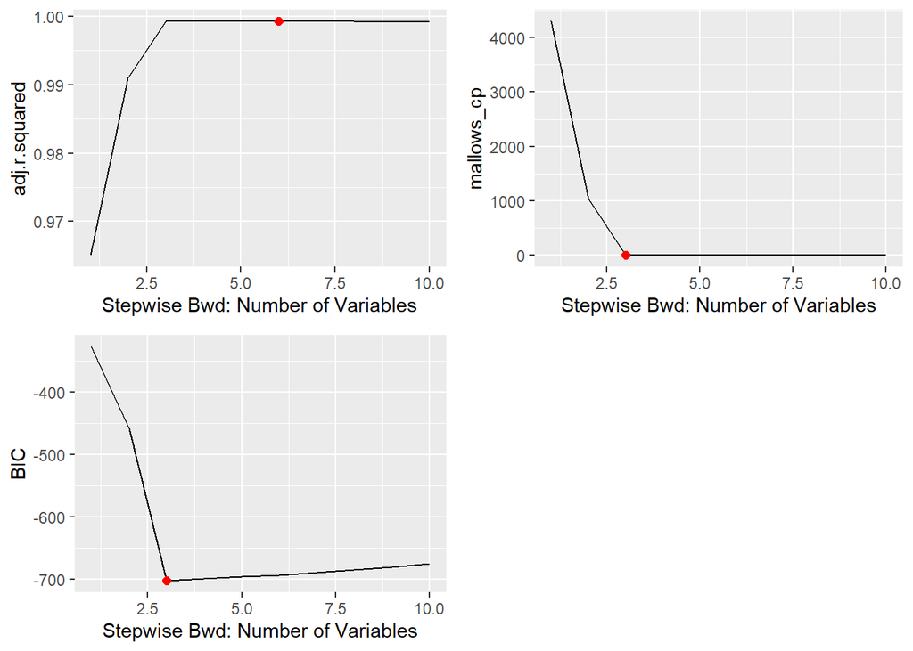

```r
grid.arrange(adjR2s_plot(regfit.bwd.sumary, "Stepwise Bwd: Number of Variables"), mallows_cps_plot(regfit.bwd.sumary, "Stepwise Bwd: Number of Variables"), BICs_plot(regfit.bwd.sumary, "Stepwise Bwd: Number of Variables"), nrow=2)
```

It is clear that BOC places the greatest penalty on increasing the number of predictors as BIC always recommends the most minimal models when comparing to other measures of fit.

## Q8 (e)

Now fit a lasso model to the simulated data, again using X,X2,. . . , X10 as predictors.

Use cross-validation to select the optimal value of λ.

Create plots of the cross-validation error as a function of λ.

Report the resulting coefficient estimates, and discuss the results obtained.

```r
library(caret)
```

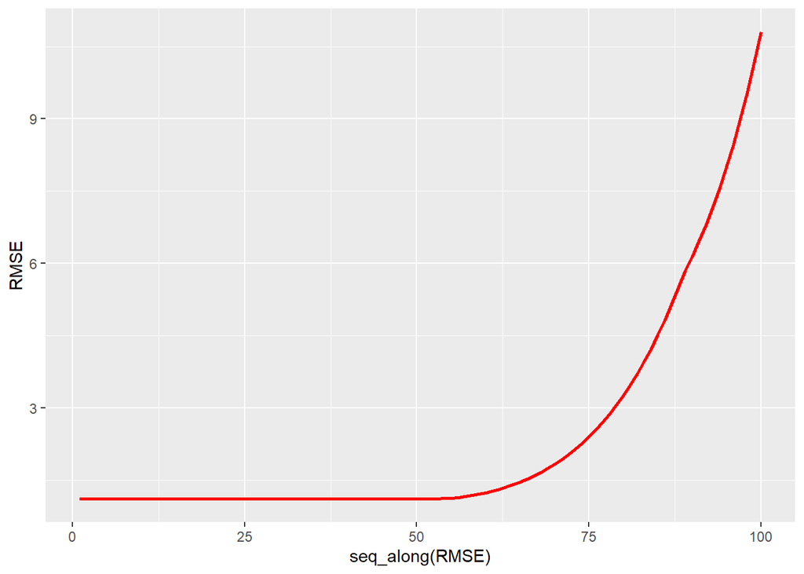

```r
set.seed(19)
# alpha 1 == lasso
lassoCV = caret::train(y~., data=df.q8c, method="glmnet",
             tuneGrid=data.frame(alpha=rep(1,100), lambda=10^seq(1,-2,length=100)),
             trControl=trainControl("cv", number=10, returnResamp='all'))

lassoCV$results %>% ggplot(aes(seq_along(RMSE), RMSE)) + geom_line(size=1, color='red')
```

```r
coef(lassoCV$finalModel, lassoCV$bestTune$lambda)
```

```
## 11 x 1 sparse Matrix of class "dgCMatrix"
##                        1
## (Intercept)  10.28378169
## x1          -12.69149653
## x2            2.75321244
## x3           -9.03713539
## x4            0.08216761
## x5            .
## x6            .
## x7            .
## x8            .
## x9            .
## x10           .
```

```r
print(paste("Best Lambda with CV: ",lassoCV$bestTune$lambda))
```

```
## [1] "Best Lambda with CV:  0.231012970008316"
```

**Answer Q8e:** Using cross-validation with lasso, the optimal value of lambda was **0.23**, and the best model, based on RMSE, is:
$$y = \beta0 + \beta1X + \beta2X^2 + \beta3X^3 + \beta4X^4$$
where:

- B0 = 10.28
- B1 = -12.6
- B2 = 2.75
- B3 = -9.04
- B4 = 0.08

These values **compare well** to the values with which I created the data set:

- B0 = 10
- B1 = -13
- B2 = 3.27
- B3 = -9.11

## Q8 (f)

Now generate a response vector Y according to the model:

Y = β0 + β7X7 + E, and perform best subset selection and the lasso.

Discuss the results obtained.

```r
# generate the new vector
B7 = 9.04
Y.Q8f = B0 + (B7 * X^7) + E
df.q8f = data.frame(x1 = X, x2 = X^2, x3 = X^3, x4 = X^4, x5 = X^5, x6 = X^6, x7 = X^7, x8 = X^8, x9 = X^9, x10 = X^10, y=Y.Q8f)

# regsubsets model
regfit.full.q8f <- leaps::regsubsets(y~., df.q8f)
reg.summary.q8f = regfit.full.q8f %>% broom::tidy()
reg.summary.q8f
```

```
## # A tibble: 8 x 15
##   `(Intercept)` x1    x2    x3    x4    x5    x6    x7    x8    x9    x10
##   <lgl>         <lgl> <lgl> <lgl> <lgl> <lgl> <lgl> <lgl> <lgl> <lgl> <lgl>
## 1 TRUE          FALSE FALSE FALSE FALSE FALSE FALSE TRUE  FALSE FALSE FALSE
## 2 TRUE          FALSE FALSE FALSE FALSE FALSE FALSE TRUE  TRUE  FALSE FALSE
## 3 TRUE          FALSE TRUE  FALSE FALSE FALSE TRUE  TRUE  FALSE FALSE FALSE
## 4 TRUE          FALSE FALSE FALSE FALSE FALSE TRUE  TRUE  TRUE  FALSE TRUE
## 5 TRUE          FALSE FALSE FALSE FALSE TRUE  TRUE  TRUE  TRUE  FALSE TRUE
## 6 TRUE          FALSE FALSE TRUE  FALSE TRUE  FALSE TRUE  TRUE  TRUE  TRUE
## 7 TRUE          FALSE TRUE  TRUE  FALSE TRUE  FALSE TRUE  TRUE  TRUE  TRUE
## 8 TRUE          FALSE FALSE TRUE  TRUE  TRUE  TRUE  TRUE  TRUE  TRUE  TRUE
## # ... with 4 more variables: r.squared <dbl>, adj.r.squared <dbl>, BIC <dbl>,
## #   mallows_cp <dbl>
```

```r
# show BIC coefficients
coef(regfit.full.q8f,1) %>% broom::tidy()
```

```
## # A tibble: 2 x 2
##   names           x
##   <chr>       <dbl>
## 1 (Intercept)  9.95
## 2 x7           9.04
```

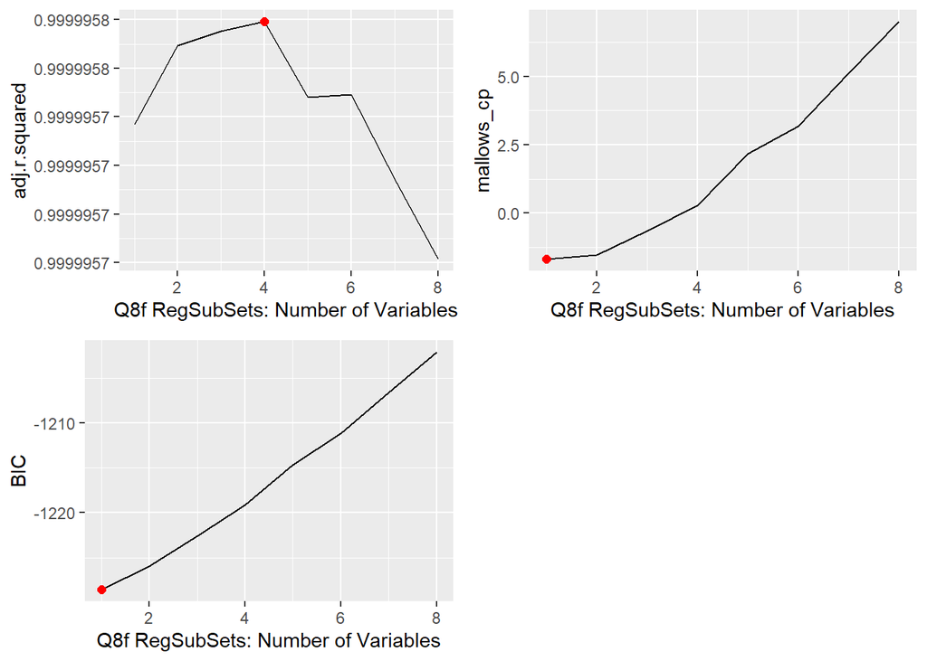

```r
grid.arrange(adjR2s_plot(reg.summary.q8f, "Q8f RegSubSets: Number of Variables"), mallows_cps_plot(reg.summary.q8f, "Q8f RegSubSets: Number of Variables"), BICs_plot(reg.summary.q8f, "Q8f RegSubSets: Number of Variables"), nrow=2)
```

```r
# fwd stepwise
regfit.fwd.q8f <- regsubsets(y~., data=df.q8f, nvmax=10, method="forward")
regfit.fwd.summary.q8f = regfit.fwd.q8f %>% broom::tidy()
regfit.fwd.summary.q8f
```

```
## # A tibble: 10 x 15
##    `(Intercept)` x1    x2    x3    x4    x5    x6    x7    x8    x9    x10
##    <lgl>         <lgl> <lgl> <lgl> <lgl> <lgl> <lgl> <lgl> <lgl> <lgl> <lgl>
##  1 TRUE          FALSE FALSE FALSE FALSE FALSE FALSE TRUE  FALSE FALSE FALSE
##  2 TRUE          FALSE FALSE FALSE FALSE FALSE FALSE TRUE  TRUE  FALSE FALSE
##  3 TRUE          FALSE TRUE  FALSE FALSE FALSE FALSE TRUE  TRUE  FALSE FALSE
##  4 TRUE          FALSE TRUE  FALSE FALSE FALSE FALSE TRUE  TRUE  FALSE TRUE
##  5 TRUE          FALSE TRUE  FALSE FALSE FALSE TRUE  TRUE  TRUE  FALSE TRUE
##  6 TRUE          FALSE TRUE  FALSE FALSE TRUE  TRUE  TRUE  TRUE  FALSE TRUE
##  7 TRUE          TRUE  TRUE  FALSE FALSE TRUE  TRUE  TRUE  TRUE  FALSE TRUE
##  8 TRUE          TRUE  TRUE  FALSE FALSE TRUE  TRUE  TRUE  TRUE  TRUE  TRUE
##  9 TRUE          TRUE  TRUE  TRUE  FALSE TRUE  TRUE  TRUE  TRUE  TRUE  TRUE
## 10 TRUE          TRUE  TRUE  TRUE  TRUE  TRUE  TRUE  TRUE  TRUE  TRUE  TRUE
## # ... with 4 more variables: r.squared <dbl>, adj.r.squared <dbl>, BIC <dbl>,
## #   mallows_cp <dbl>
```

```r
# show BIC coefficients
coef(regfit.fwd.q8f,1) %>% broom::tidy()
```

```
## # A tibble: 2 x 2
##   names           x
##   <chr>       <dbl>
## 1 (Intercept)  9.95
## 2 x7           9.04
```

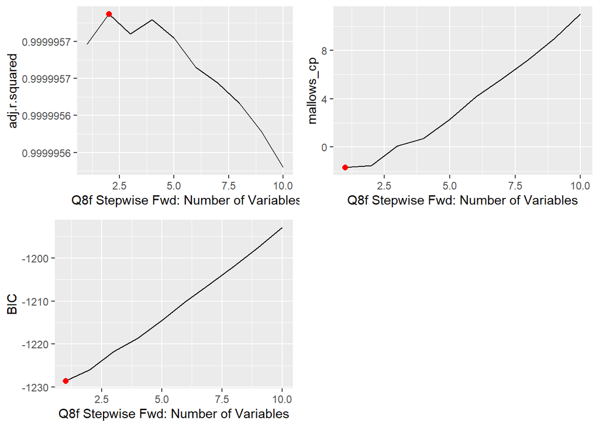

```r
grid.arrange(adjR2s_plot(regfit.fwd.summary.q8f, " Q8f Stepwise Fwd: Number of Variables"), mallows_cps_plot(regfit.fwd.summary.q8f, "Q8f Stepwise Fwd: Number of Variables"), BICs_plot(regfit.fwd.summary.q8f, "Q8f Stepwise Fwd: Number of Variables"), nrow=2)
```

```r
# bwd stepwise
regfit.bwd.q8f <- regsubsets(y~., data=df.q8f, nvmax=10, method="backward")
regfit.bwd.summary.q8f = regfit.bwd.q8f %>% broom::tidy()
regfit.bwd.summary.q8f
```

```
## # A tibble: 10 x 15
##    `(Intercept)` x1    x2    x3    x4    x5    x6    x7    x8    x9    x10
##    <lgl>         <lgl> <lgl> <lgl> <lgl> <lgl> <lgl> <lgl> <lgl> <lgl> <lgl>
##  1 TRUE          FALSE FALSE FALSE FALSE FALSE FALSE TRUE  FALSE FALSE FALSE
##  2 TRUE          FALSE FALSE FALSE FALSE TRUE  FALSE TRUE  FALSE FALSE FALSE
##  3 TRUE          FALSE FALSE FALSE FALSE TRUE  FALSE TRUE  FALSE TRUE  FALSE
##  4 TRUE          FALSE FALSE TRUE  FALSE TRUE  FALSE TRUE  FALSE TRUE  FALSE
##  5 TRUE          FALSE FALSE TRUE  FALSE TRUE  FALSE TRUE  FALSE TRUE  TRUE
##  6 TRUE          FALSE FALSE TRUE  FALSE TRUE  FALSE TRUE  TRUE  TRUE  TRUE
##  7 TRUE          FALSE FALSE TRUE  TRUE  TRUE  FALSE TRUE  TRUE  TRUE  TRUE
##  8 TRUE          FALSE FALSE TRUE  TRUE  TRUE  TRUE  TRUE  TRUE  TRUE  TRUE
##  9 TRUE          FALSE TRUE  TRUE  TRUE  TRUE  TRUE  TRUE  TRUE  TRUE  TRUE
## 10 TRUE          TRUE  TRUE  TRUE  TRUE  TRUE  TRUE  TRUE  TRUE  TRUE  TRUE
## # ... with 4 more variables: r.squared <dbl>, adj.r.squared <dbl>, BIC <dbl>,
## #   mallows_cp <dbl>
```

```r
# show BIC coefficients
coef(regfit.bwd.q8f,1) %>% broom::tidy()
```

```
## # A tibble: 2 x 2
##   names           x
##   <chr>       <dbl>
## 1 (Intercept)  9.95
## 2 x7           9.04
```

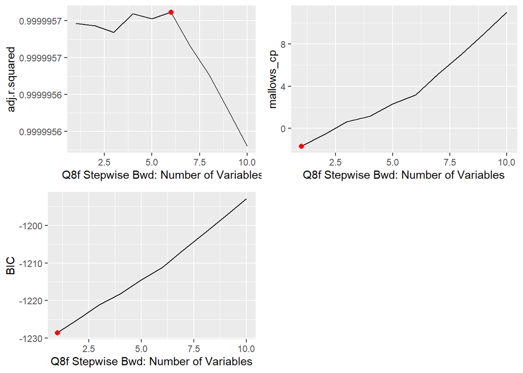

```r
grid.arrange(adjR2s_plot(regfit.bwd.summary.q8f, " Q8f Stepwise Bwd: Number of Variables"), mallows_cps_plot(regfit.bwd.summary.q8f, "Q8f Stepwise Bwd: Number of Variables"), BICs_plot(regfit.bwd.summary.q8f, "Q8f Stepwise Bwd: Number of Variables"), nrow=2)
```

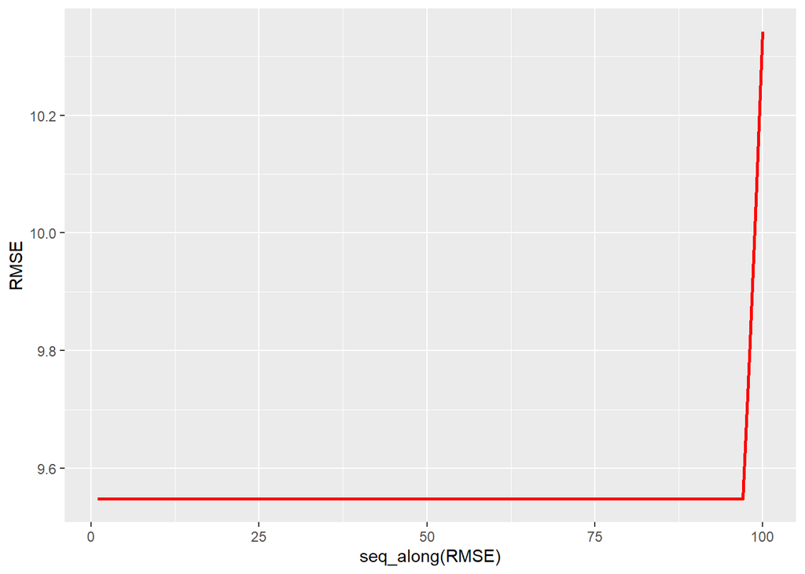

```r
# lasso
set.seed(1976)
# alpha 1 == lasso
lassoCV.q8f = caret::train(y~., data=df.q8f, method="glmnet",
             tuneGrid=data.frame(alpha=rep(1,100), lambda=10^seq(1,-2,length=100)),
             trControl=trainControl("cv", number=10, returnResamp='all'))

lassoCV.q8f$results %>% ggplot(aes(seq_along(RMSE), RMSE)) + geom_line(size=1, color='red')
```

```r
coef(lassoCV.q8f$finalModel, lassoCV.q8f$bestTune$lambda)
```

```
## 11 x 1 sparse Matrix of class "dgCMatrix"
##                    1
## (Intercept) 7.776879
## x1          .
## x2          .
## x3          .
## x4          .
## x5          .
## x6          .
## x7          8.776030
## x8          .
## x9          .
## x10         .
```

```r
lassoCV.q8f$bestTune$lambda
```

```
## [1] 8.111308
```

**Answer Q8f:**

The **true** model is:
$$y = 10 + (9.04 * X^7) + E$$

The function with regsubsets, fwd selection, and bwd selection estimated coefficients as identified in the best BIC model are:
$$y = 9.95 + (9.04 * X^7)$$
This is **very close** to the true model.

Using the **lasso** the model identified uses lambda of **8.1** and is defined:
$$y = 7.78 + (8.78 * X^7)$$
The lasso did not get as close to the true values as the subset selection methods did.

# Question 9

In this exercise, we will predict the number of applications received using the other variables in the College data set.

## Q9 (a)

Split the data set into a training set and a test set.

```r
library(ISLR)
head(College)
```

```
##                              Private Apps Accept Enroll Top10perc Top25perc
## Abilene Christian University     Yes 1660   1232    721        23        52
## Adelphi University               Yes 2186   1924    512        16        29
## Adrian College                   Yes 1428   1097    336        22        50
## Agnes Scott College              Yes  417    349    137        60        89
## Alaska Pacific University        Yes  193    146     55        16        44
## Albertson College                Yes  587    479    158        38        62
##                              F.Undergrad P.Undergrad Outstate Room.Board Books
## Abilene Christian University        2885         537     7440       3300   450
## Adelphi University                  2683        1227    12280       6450   750
## Adrian College                      1036          99    11250       3750   400
## Agnes Scott College                  510          63    12960       5450   450
## Alaska Pacific University            249         869     7560       4120   800
## Albertson College                    678          41    13500       3335   500
##                              Personal PhD Terminal S.F.Ratio perc.alumni Expend
## Abilene Christian University     2200  70       78      18.1          12   7041
## Adelphi University               1500  29       30      12.2          16  10527
## Adrian College                   1165  53       66      12.9          30   8735
## Agnes Scott College               875  92       97       7.7          37  19016
## Alaska Pacific University        1500  76       72      11.9           2  10922
## Albertson College                 675  67       73       9.4          11   9727
##                              Grad.Rate
## Abilene Christian University        60
## Adelphi University                  56
## Adrian College                      54
## Agnes Scott College                 59
## Alaska Pacific University           15
## Albertson College                   55
```

```r
#dim(College)
```

```r
library(caret)

set.seed(1976)
college = sample_n(College, nrow(College))
train_indices = sample(1:nrow(College), nrow(College) * .75)

college_train = College[train_indices,]
college_test = College[-train_indices,]
```

## Q9 (b)

Fit a linear model using least squares on the training set, and report the test error obtained.

```r
model.lm = lm(Apps ~ ., data = college_train)
broom::glance(model.lm)
```

```
## # A tibble: 1 x 12
##   r.squared adj.r.squared sigma statistic   p.value    df logLik   AIC   BIC
##       <dbl>         <dbl> <dbl>     <dbl>     <dbl> <dbl>  <dbl> <dbl> <dbl>
## 1     0.927         0.925 1088.      420. 7.54e-307    17 -4886. 9810. 9893.
## # ... with 3 more variables: deviance <dbl>, df.residual <int>, nobs <int>
```

```r
model.glm_predictions = broom::augment(model.lm, newdata=college_test)

#model.glm_predictions
mean((model.glm_predictions$Apps-model.glm_predictions$.fitted)^2)
```

```
## [1] 879419.2
```

**Answer Q9b:** The MLR model has an MSE of 879419.2 from the test data.

## Q9 (c)

Fit a ridge regression model on the training set, with λ chosen by cross-validation.

Report the test error obtained.

**Here is the training**

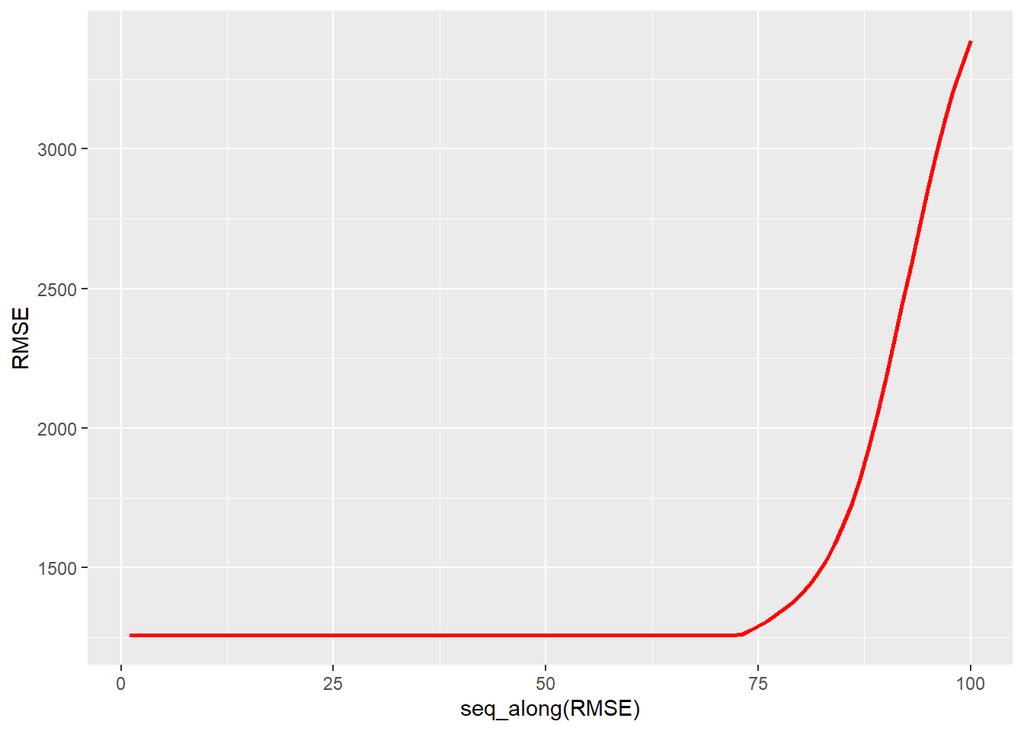

```r
# ridge
set.seed(1976)
# alpha 0 == ridge
ridge.q9c = caret::train(Apps ~ ., data=college_train, method="glmnet",
             tuneGrid=data.frame(alpha=rep(0,100), lambda=10^seq(5,-4,length=100)),
             trControl=trainControl("cv", number=10, returnResamp='all'))

ridge.q9c$results %>% ggplot(aes(seq_along(RMSE), RMSE)) + geom_line(size=1, color='red')
```

```r
coef(ridge.q9c$finalModel, ridge.q9c$bestTune$lambda)
```

```
## 18 x 1 sparse Matrix of class "dgCMatrix"
##                         1
## (Intercept) -1.397756e+03
## PrivateYes  -5.189246e+02
## Accept       1.040627e+00
## Enroll       3.865649e-01
## Top10perc    2.556732e+01
## Top25perc   -8.877736e-03
## F.Undergrad  8.703037e-02
## P.Undergrad -4.552995e-02
## Outstate    -3.063606e-02
## Room.Board   1.849582e-01
## Books        5.850737e-02
## Personal     1.502346e-02
## PhD         -2.719999e+00
## Terminal    -4.781361e+00
## S.F.Ratio    9.025293e+00
## perc.alumni -6.627478e+00
## Expend       7.398459e-02
## Grad.Rate    1.137273e+01
```

```r
ridge.q9c$bestTune$lambda
```

```
## [1] 284.8036
```

**Here is the test**

```r
q9c.pred = predict(ridge.q9c, newdata=college_test)

# print the MSE for the predictions
mean((college_test$Apps-q9c.pred)^2)
```

```
## [1] 860609.3
```

```r
# this would print the final model
#ridge.q9c$finalModel %>% summary()

#https://stackoverflow.com/questions/40493412/how-to-pick-a-different-model-from-the-finalmodel-in-caret
# if I wanted a different model from the one selected:
#ridge.q9c <- update(ridge.q9c, param = list(ncomp = 7))
#ridge.q9c$finalModel %>% summary()
```

**Observation Q9c:** the *test MSE* for the ridge regression is slightly lower than the linear model.

- lm: 879419.2
- ridge model: 860609.3

## Q9 (d)

Fit a lasso model on the training set, with λ chosen by cross-validation.

Report the test error obtained, along with the number of non-zero coefficient estimates.

**Here is the training**

```r
# lasso
set.seed(1976)
# alpha 1 == lasso
lasso.q9 = caret::train(Apps ~ ., data=college_train, method="glmnet",
             tuneGrid=data.frame(alpha=rep(1,100), lambda=10^seq(5,-4,length=100)),
             trControl=trainControl("cv", number=10, returnResamp='all'))
```

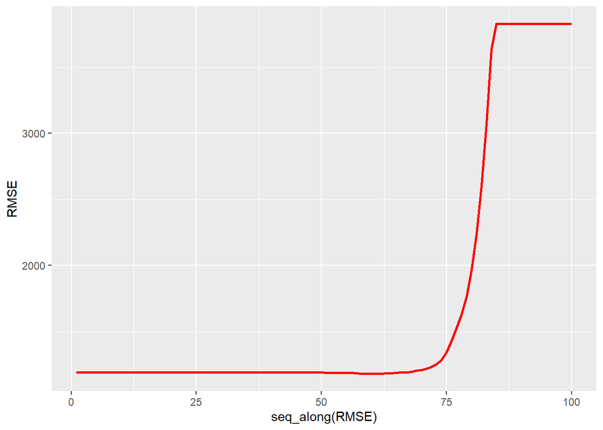

```r
lasso.q9$results %>% ggplot(aes(seq_along(RMSE), RMSE)) + geom_line(size=1, color='red')
```

```r
coef(lasso.q9$finalModel, lasso.q9$bestTune$lambda)
```

```
## 18 x 1 sparse Matrix of class "dgCMatrix"
##                         1
## (Intercept) -599.45195495
## PrivateYes  -442.87727790
## Accept         1.48335384
## Enroll        -0.24851834
## Top10perc     29.75710945
## Top25perc     -0.17766001
## F.Undergrad    .
## P.Undergrad    .
## Outstate      -0.04732921
## Room.Board     0.08992306
## Books          .
## Personal       .
## PhD           -1.65337906
## Terminal      -5.31239943
## S.F.Ratio      .
## perc.alumni    .
## Expend         0.06544648
## Grad.Rate      4.88401358
```

```r
lasso.q9$bestTune$lambda
```

```
## [1] 28.48036
```

**Here is the test**

```r
q9d.pred = predict(lasso.q9, newdata=college_test)

# print the MSE for the predictions
mean((college_test$Apps-q9d.pred)^2)
```

```
## [1] 809997.9
```

**Observations Q9d:** The MSE for the lasso model is much less than the linear model, and less than the ridge model:

- lm: 879419.2
- ridge model: 860609.3
- lasso model: 809997.9

And, of the predictors, there are *11 with non-zero coefficients* using the lasso:

1. PrivateYes: -442.87727790
2. Accept: 1.48335384
3. Enroll: -0.24851834
4. Top10perc: 29.75710945
5. Top25perc: -0.17766001
6. Outstate: -0.04732921
7. Room.Board: 0.08992306
8. PhD: -1.65337906
9. Terminal: -5.31239943
10. Expend: 0.06544648
11. Grad.Rate: 4.88401358

## Q9 (e)

Fit a PCR model on the training set, with M chosen by cross-validation.

Report the test error obtained, along with the value of M selected by cross-validation.

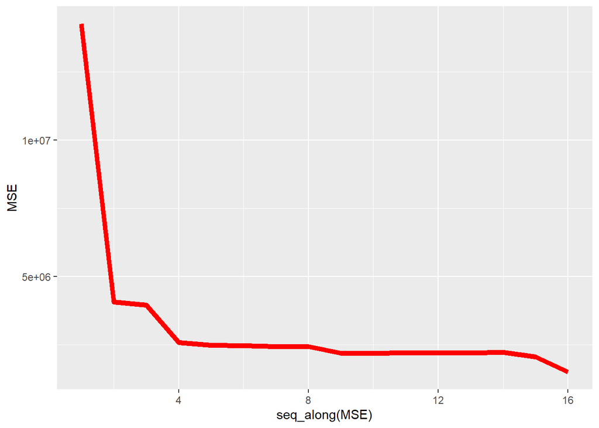

```r
set.seed(1976)

# use the pcr model - requires standardization: for 17 parameters
q9epcr.fits = train(Apps~., data=college_train, method="pcr", tuneLength=16, scale=TRUE, trControl=trainControl("cv", number=10, returnResamp='all'))

# plot the MSE as
q9epcr.fits$results %>% dplyr::mutate(MSE=RMSE^2) %>% ggplot(aes(seq_along(MSE), MSE)) + geom_line(size=2, color='red')
```

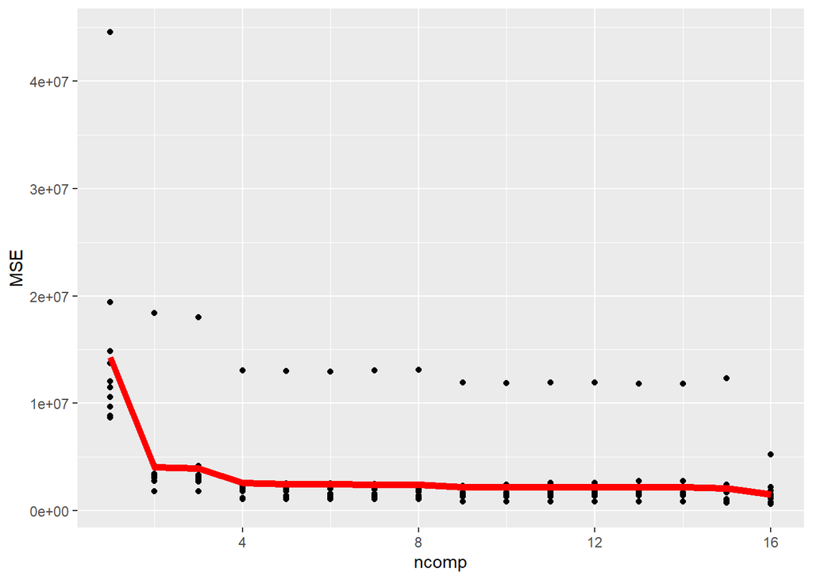

```r
q9epcr.fits$resample %>%
  dplyr::mutate(MSE=RMSE^2) %>%
  dplyr::group_split(Resample) %>%
  dplyr::bind_rows() %>%
  ggplot(aes(ncomp, MSE)) + geom_point() +
  geom_line(q9epcr.fits$results%>%dplyr::mutate(MSE=RMSE^2),
            mapping=aes(seq_along(MSE), MSE),
            size=2, color='red')
```

```r
summary(q9epcr.fits)
```

```
## Data:    X dimension: 582 17
##  Y dimension: 582 1
## Fit method: svdpc
## Number of components considered: 16
## TRAINING: % variance explained
##           1 comps  2 comps  3 comps  4 comps  5 comps  6 comps  7 comps
## X          32.402    57.90    64.73    70.73    76.14    81.19    84.76
## .outcome    2.854    71.36    72.44    82.71    82.74    82.82    82.97
##           8 comps  9 comps  10 comps  11 comps  12 comps  13 comps  14 comps
## X           87.97    90.66     92.96     95.15     96.91     98.00     98.76
## .outcome    83.10    85.05     85.12     85.18     85.19     85.38     85.39
##           15 comps  16 comps
## X            99.35     99.83
## .outcome     90.40     92.16
```

```r
# get the predictions
q9epcr.pred <- predict(q9epcr.fits, newdata=college_test)

mean((college_test$Apps-q9epcr.pred)^2)
```

```
## [1] 843803.1
```

```r
q9epcr.fits$finalModel %>% summary()
```

```
## Data:    X dimension: 582 17
##  Y dimension: 582 1
## Fit method: svdpc
## Number of components considered: 16
## TRAINING: % variance explained
##           1 comps  2 comps  3 comps  4 comps  5 comps  6 comps  7 comps
## X          32.402    57.90    64.73    70.73    76.14    81.19    84.76
## .outcome    2.854    71.36    72.44    82.71    82.74    82.82    82.97
##           8 comps  9 comps  10 comps  11 comps  12 comps  13 comps  14 comps
## X           87.97    90.66     92.96     95.15     96.91     98.00     98.76
## .outcome    83.10    85.05     85.12     85.18     85.19     85.38     85.39
##           15 comps  16 comps
## X            99.35     99.83
## .outcome     90.40     92.16
```

**Observations Q9e:** The MSE for the PCR model where cross-validation selected M = 16 is between the ridge and lasso models.

- lm: 879419.2
- ridge model: 860609.3
- lasso model: 809997.9
- PCR | M == 16: 843803.1

## Q9 (f)

Fit a PLS (Partial Least Squares) model on the training set, with M chosen by cross-validation.

Report the test error obtained, along with the value of M selected by cross-validation.

```r
set.seed(1976)

q9fpls.fits = train(Apps~., data=college_train, method="pls", tuneLength=17, scale=TRUE, trControl=trainControl("cv", number=10, returnResamp='all'))

#summary(pls.fit)
q9fpls.fits$finalModel %>% summary()
```

```
## Data:    X dimension: 582 17
##  Y dimension: 582 1
## Fit method: oscorespls
## Number of components considered: 12
## TRAINING: % variance explained
##           1 comps  2 comps  3 comps  4 comps  5 comps  6 comps  7 comps
## X           25.75    43.14    63.64    66.27    70.04    74.03    77.44
## .outcome    76.79    83.51    86.64    89.96    91.67    92.42    92.49
##           8 comps  9 comps  10 comps  11 comps  12 comps
## X           80.17    83.04     84.92     88.28     91.40
## .outcome    92.56    92.61     92.65     92.66     92.67
```

View MSE as number of components changes, and for each fold.

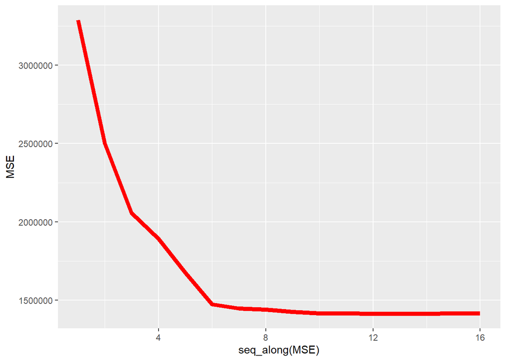

```r
q9fpls.fits$results %>% dplyr::mutate(MSE=RMSE^2) %>% ggplot(aes(seq_along(MSE), MSE)) + geom_line(size=2, color='red')
```

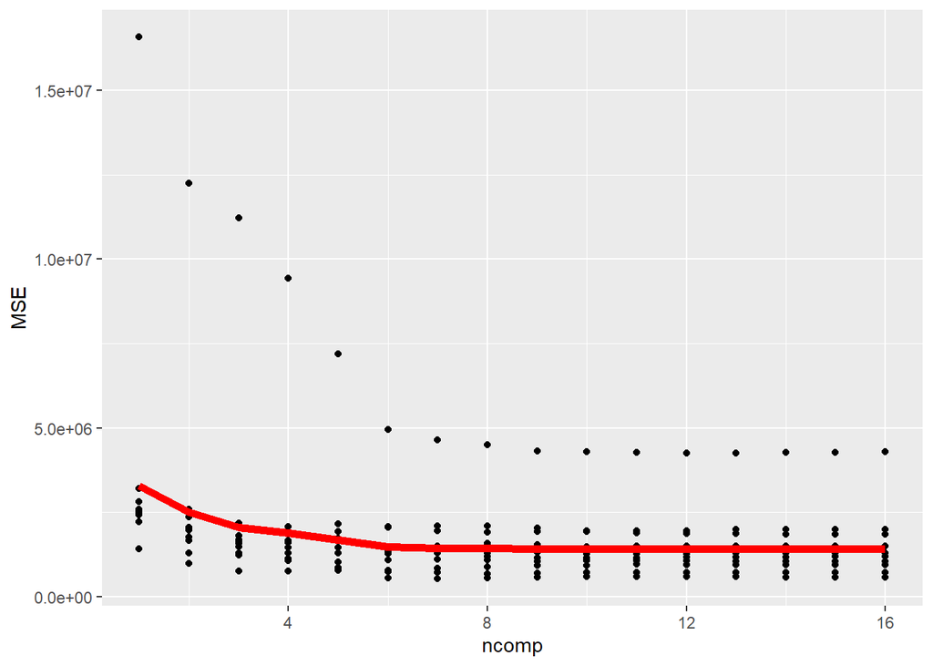

```r
q9fpls.fits$resample %>%
  dplyr::mutate(MSE=RMSE^2) %>%
  dplyr::group_split(Resample) %>%
  dplyr::bind_rows() %>%
  ggplot(aes(ncomp, MSE)) + geom_point() +
  geom_line(q9fpls.fits$results%>%dplyr::mutate(MSE=RMSE^2),
            mapping=aes(seq_along(MSE), MSE),
            size=2, color='red')
```

```r
q9fpls.pred = predict(q9fpls.fits, newdata=college_test)
#mean((pls.pred-y.test)^2)
mean((college_test$Apps-q9fpls.pred)^2)
```

```
## [1] 876331.9
```

```r
q9fpls.fits$finalModel %>% summary()
```

```
## Data:    X dimension: 582 17
##  Y dimension: 582 1
## Fit method: oscorespls
## Number of components considered: 12
## TRAINING: % variance explained
##           1 comps  2 comps  3 comps  4 comps  5 comps  6 comps  7 comps
## X           25.75    43.14    63.64    66.27    70.04    74.03    77.44
## .outcome    76.79    83.51    86.64    89.96    91.67    92.42    92.49
##           8 comps  9 comps  10 comps  11 comps  12 comps
## X           80.17    83.04     84.92     88.28     91.40
## .outcome    92.56    92.61     92.65     92.66     92.67
```

**Observations Q9f:** The MSE for the PLS model where cross-validation selected M = 12 is only slightly better performing on the test data than the linear model.

- lm: 879419.2
- ridge model: 860609.3
- lasso model: 809997.9
- PCR | M == 16: 843803.1
- PLS | M == 12: 876331.9

## Q9 (g)

Comment on the results obtained. How accurately can we predict the number of college applications received? Is there much difference among the test errors resulting from these five approaches?

```r
lasso.tibble = as_tibble(lasso.q9$results)

lasso.tibble %>% filter(RMSE == min(RMSE))
```

```
## # A tibble: 1 x 8
##   alpha lambda  RMSE Rsquared   MAE RMSESD RsquaredSD MAESD
##   <dbl>  <dbl> <dbl>    <dbl> <dbl>  <dbl>      <dbl> <dbl>
## 1     1   28.5 1178.    0.915  636.   407.     0.0482  108.
```

```r
#lasso.q9$finalModel %>% summary()

#lasso.q9$finalModel$tuneValue

calc.RSquare = function(actual,predict){
  cor(actual,predict)^2
}

calc.RSquare(college_test$Apps, q9d.pred)
```

```
## [1] 0.9372137
```

**Answer Q9g:** The best performing model using the measure of MSE is the lasso model, which has an R Squared value of .937. This tells use that the model selected using a lambda of 28.5 and using the following 11 predictors predicts 93.7% of the variance in the number of applications to the universities in the sample.

1. PrivateYes: -442.87727790
2. Accept: 1.48335384
3. Enroll: -0.24851834
4. Top10perc: 29.75710945
5. Top25perc: -0.17766001
6. Outstate: -0.04732921
7. Room.Board: 0.08992306
8. PhD: -1.65337906
9. Terminal: -5.31239943
10. Expend: 0.06544648
11. Grad.Rate: 4.88401358